# SDS315 - Homework 2

#### Name: Maria Berroa

#### UTEID: mpb2544

#### GitHub: https://github.com/MariaBerroa/SDS315_Homework2.git

#### **Problem 1: Beauty, or not, in the classroom**

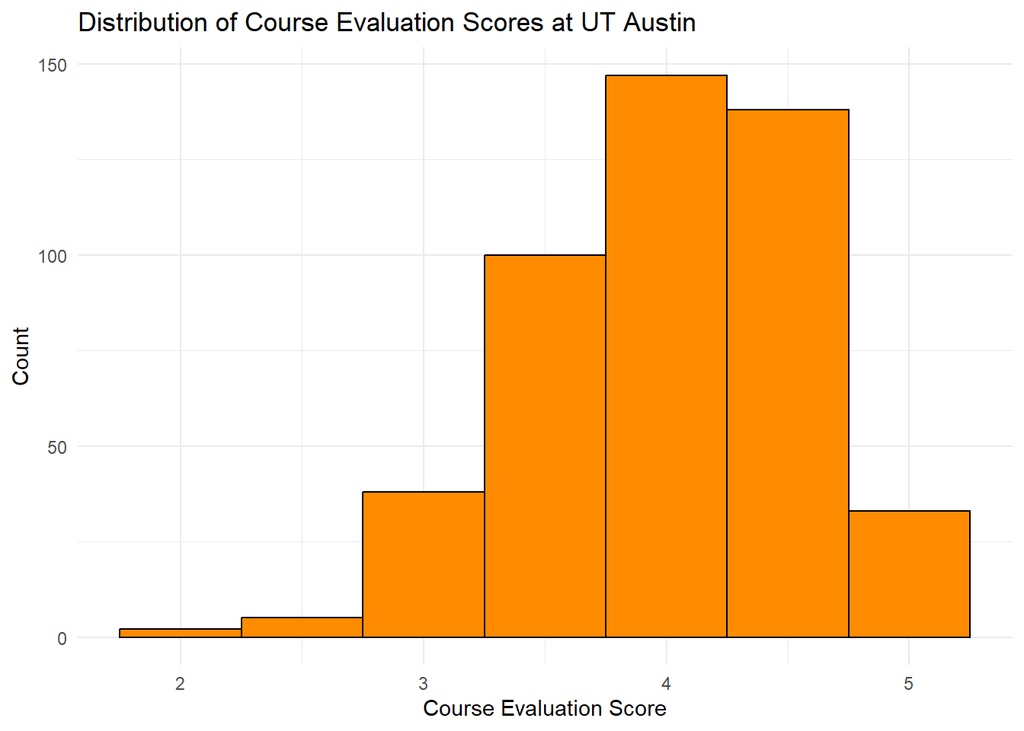

#### Figure 1:

##### The Histogram above displays the overall data distribution of course evaluation scores of 463 UT Austin Courses. The course evaluation scores range from 1 as the lowest and 5 as the highest. Our histogram shows that the average course evaluation score was 3.99, while the lowest was 2.1 and the higest 5.0.

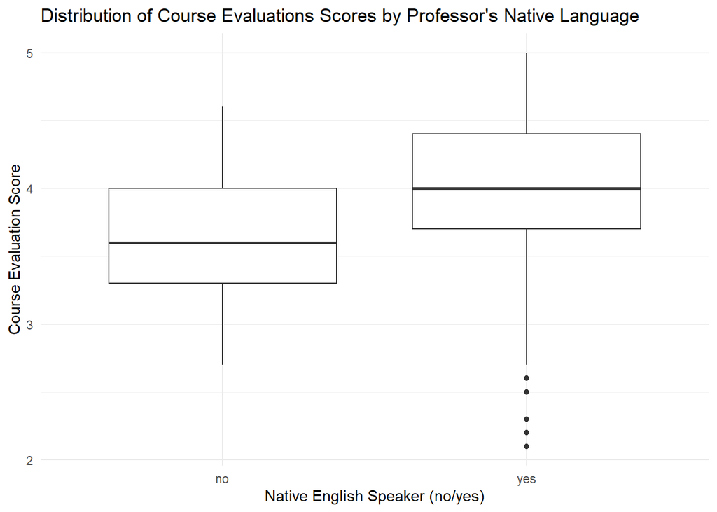

#### Figure 2:

##### The boxplots above show a side to side comparison of the distribution of course evaluation scores dependant on the Professor’s native language.As seen, it is evident that Professors who are native English speakers, received much higer course evaluation scores than those who aren’t.

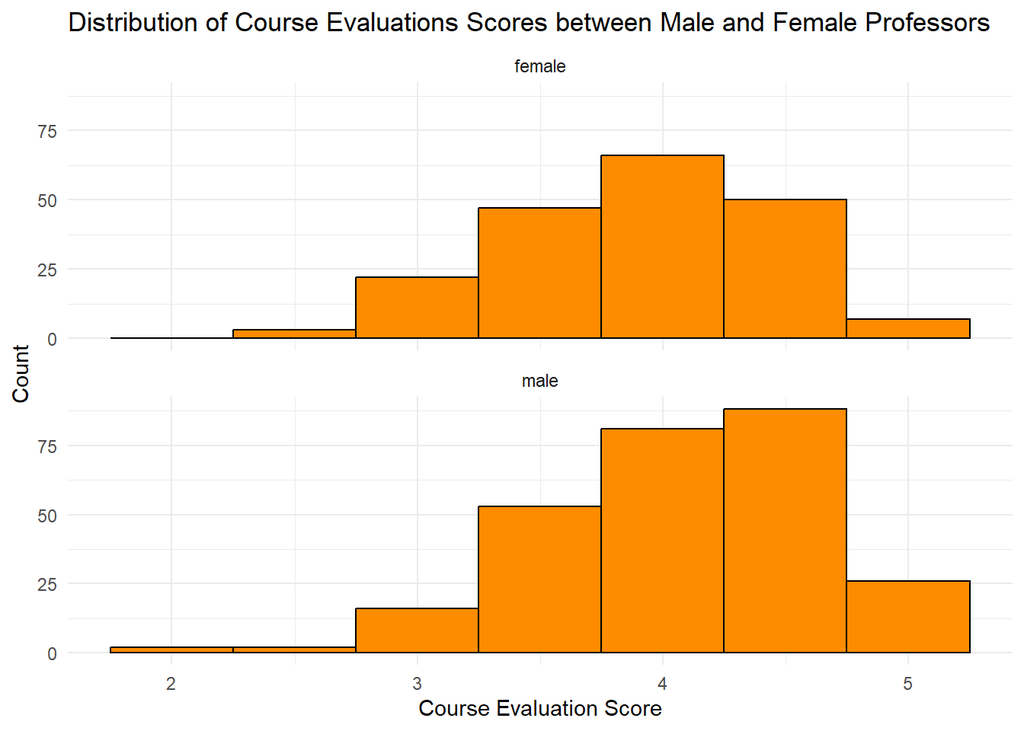

#### Figure 3:

##### The histogram above shows a comparison of course evaluation scores between male vs. female Professors. Female Professors received a minimum socre of 2.3, an average score of 3.9, and a maximum score of 4.9. On the other hand, Male Professors received a minimum score of 2.1, an average score of 4.1, and a maximum of 5.0.

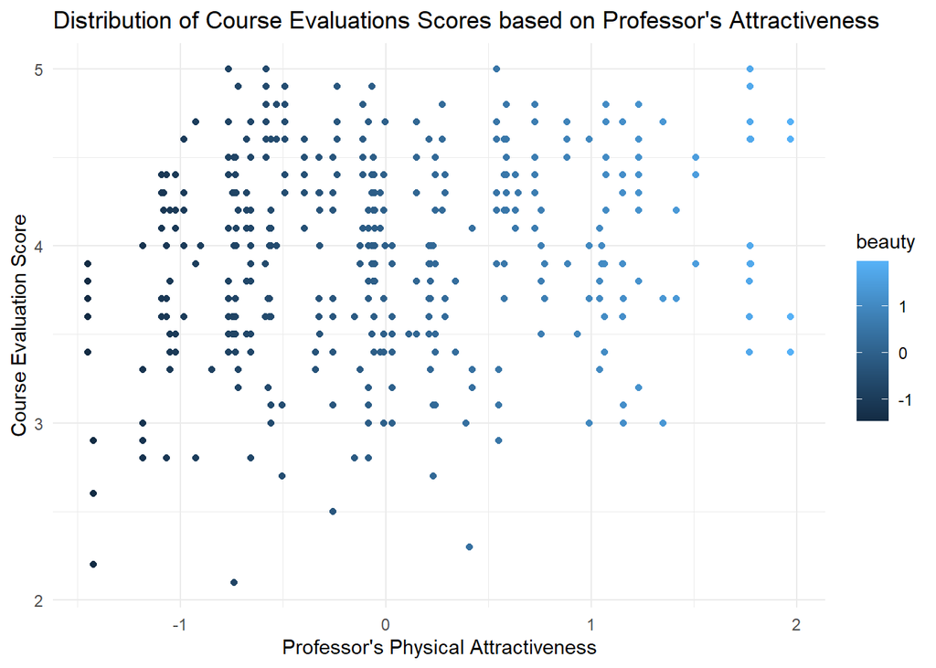

#### **Problem 2: Bike Sharing**

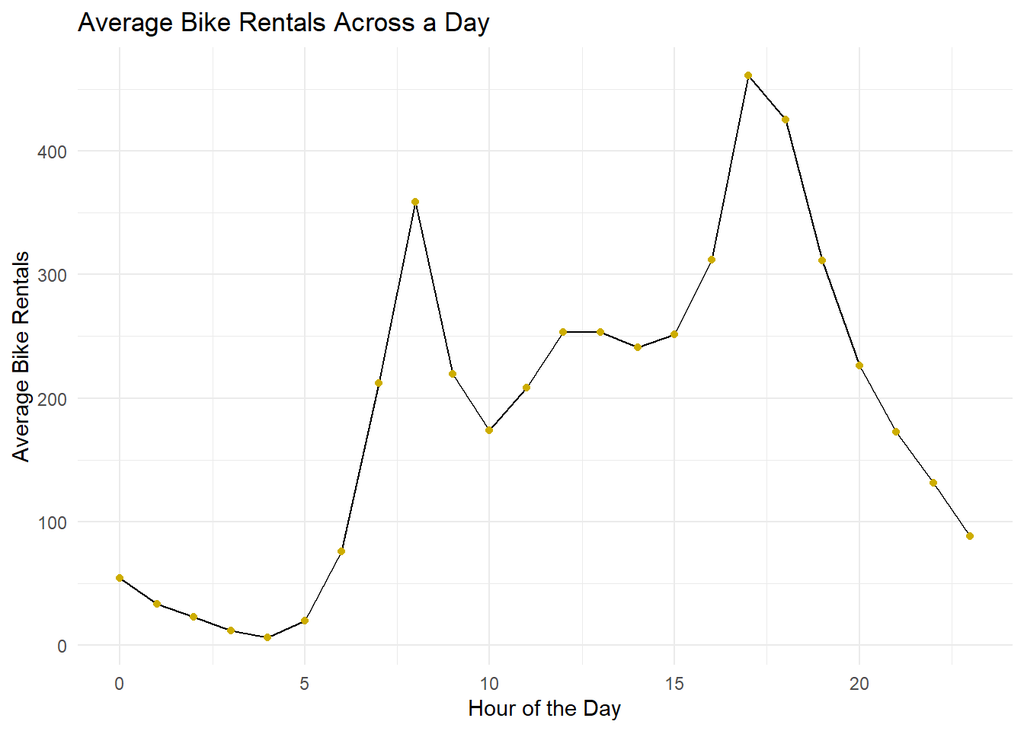

#### Figure 5:

[figure not shown]

#### Figure 6:

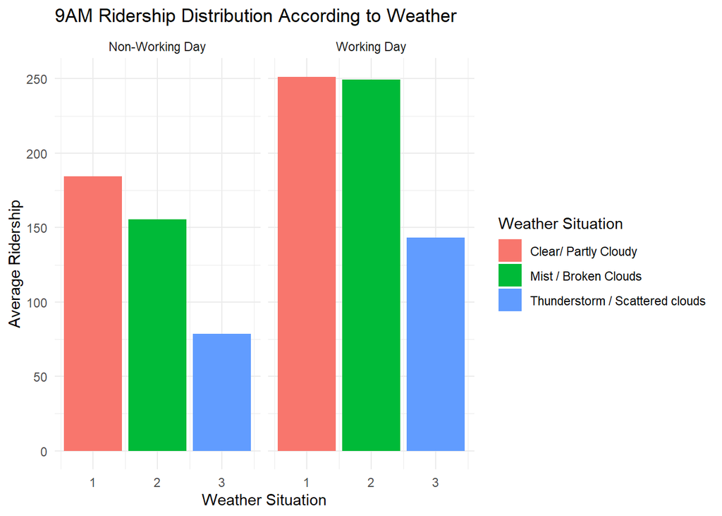

### **Problem 3: Capital Metro UT Ridership**

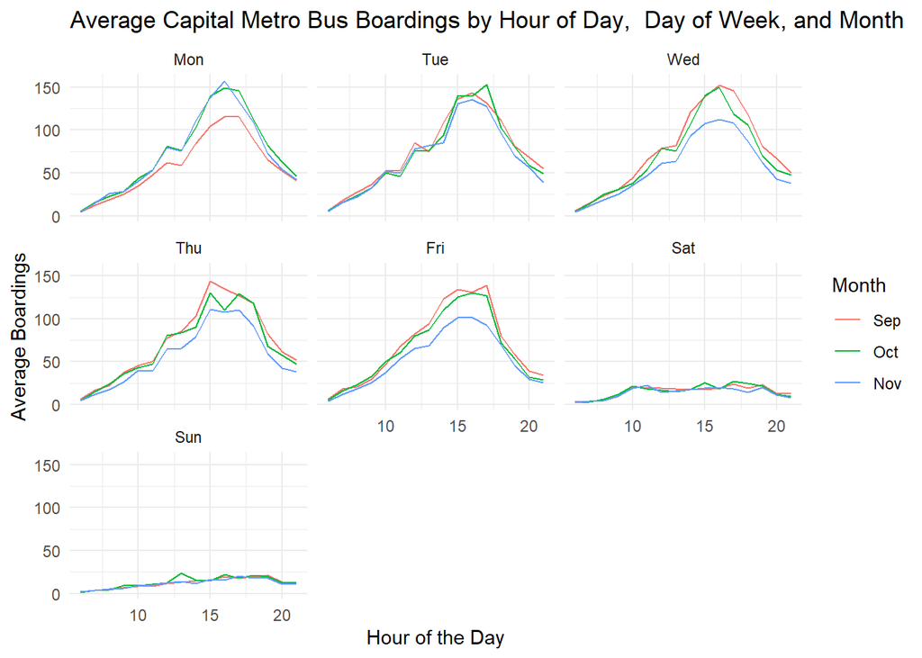

#### Figure 8:

##### The line graphs above show the average Capital Metro Bus Boardings by hour of the day, day of the week, and month. Each graph has an x-axis which represents the hour of the day. A y-axis that represents the boarding count, and three lines that represent the months of September, October, and November. We learn from the figure, that the hour of peak boardings during the week ranges from 3pm to 5:30pm, showing a strong similarity across all days. However, the hour of peak boardings during the weekends shows an abrupt change if compared to the weekdays. I think average boardings on Mondays in September look lower, compared to other days and months because during this time period we see the start of the academic year. This could mean that people might switch out from this transportation method, or simply walk to class. In addition, I think average boardings on Weds/Thurs?Fri in November look lower because it could be considered the start of the holiday season. A lot of people gather with their families and either stay at home or have another transportation method. In addition, it is a month in which the weather starts getting cold, which may lead to less people opting to ride the metro.

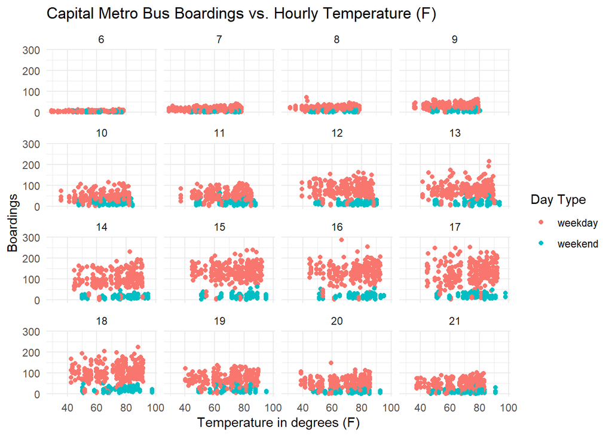

#### Figure 9:

##### The figure above shows 16 scatterplots. Each scatterplot represents information on bus boardings vs. temperature by every hour of the day. Starting at 6:00am and ending at 9:00pm. The x-axis represents temperature in degrees (F), and it ranges from 40 to 100. The y-axis represents the count of the boardings. On the right side we have a legend. The legend conveys that pink points on the scatterplot represent weekdays, while blue dots on the scatterplot represent weekends. From the figure we learn that when we hold hour of day and weekend status constant temperature does not seem to have a noticeable effect on the number of UT students riding the month. In this case, the only noticeable effect that temperature has on the number of UT students riding the bus is from 3:00pm to 6:00pm when the temperature raises to 70 degrees(F) or higher.

### **Problem 4: Wrangling the Billboard Top 100**

##### **Part A:**

| performer | song | week_total |
| --- | --- | --- |
| Imagine Dragons | Radioactive | 87 |
| AWOLNATION | Sail | 79 |
| Jason Mraz | I’m Yours | 76 |
| The Weeknd | Blinding Lights | 76 |
| LeAnn Rimes | How Do I Live | 69 |
| LMFAO Featuring Lauren Bennett & GoonRock | Party Rock Anthem | 68 |
| OneRepublic | Counting Stars | 68 |
| Adele | Rolling In The Deep | 65 |
| Jewel | Foolish Games/You Were Meant For Me | 65 |
| Carrie Underwood | Before He Cheats | 64 |

#### Figure 10:

##### The table above shows the top 10 MOST popular songs since the year 1958. At the top of the table we have “Radioctive” spending 87 total weeks on the billboard Top 100. On the other hand, we have “Before He Cheats” at the end of the table, speding 64 total weeks on the billboard Top 100.

[figure not shown]

#### Figure 11:

##### The line graph above shows the number of unique songs appearing on the Billboard top 100 across the years. The years ranges from 1959 to 2020. And the number of unique songs, ranges from 400 to 800. Some interesting trens I see is that the graph is not linear. When thinking about music, I would assume that as years progress, the music industry grows and gets more creative, thus increasing the number of unique songs that become hits. There was a sharp decline of unique songs appearing on the billboard for almost 30 years. However, at the start of the 2000s we saw a moderate increase.

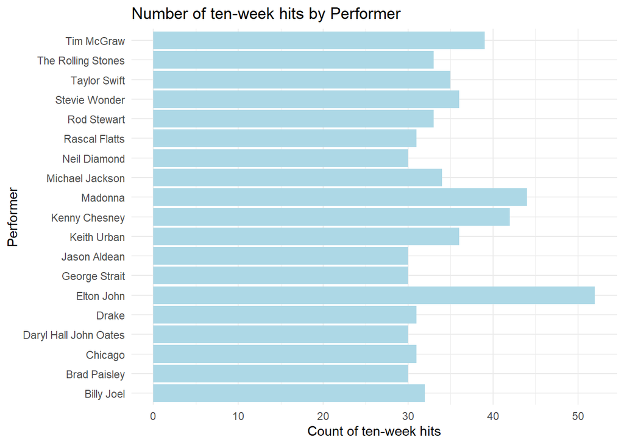

#### Figure 12:

##### The Bar Plot above, shows the number of ten-week hits (songs) on the Billboard Top 100 that each performer has acomplished. This information ranges from years 1958 to 2021. The figures shows that performers such as Elotn John, Madonna, and Kenny Chesney surpassed other performers by having at least 40 songs considered a ten-week hit. The graph also shows that the average count of ten-week hits was 34. While the minimum was 30 and the maximum was 52.